# Transcription factor binding site (TFBS) analysis with the “TFBSTools” package

Ge Tan

29 October 2019

#### Abstract

Analysis and manipulation of transcription factor binding sites.

#### Package

TFBSTools 1.24.0

# 1 Introduction

Eukaryotic regulatory regions are characterized based a set of discovered transcription factor binding sites (TFBSs), which can be represented as sequence patterns with various degree of degeneracy.

This *TFBSTools* package is designed to be a compuational framework for TFBSs analysis. Based on the famous perl module TFBS (Lenhard and Wasserman 2002), we extended the class definitions and enhanced implementations in an interactive environment. So far this package contains a set of integrated *R* *S4* style classes, tools, JASPAR database interface functions. Most approaches can be described in three sequential phases. First, a pattern is generated for a set of target sequences known to be bound by a specific transcription factor. Second, a set of DNA sequences are analyzed to determine the locations of sequences consistent with the described binding pattern. Finally, in advanced cases, predictive statistical models of regulatory regions are constructed based on mutiple occurrences of the detected patterns.

Since JASPAR2016, the next generation of transcription factor binding site, *TFFM* (Mathelier and Wasserman 2013), was introduced into JASPAR for the first time. Now *TFBSTools* also supports the manipulation of *TFFM*. TFFM is based on hidden Markov Model (HMM). The biggest advantage of TFFM over basic PWM is that it can model position interdependence within TFBSs and variable motif length. A novel graphical representation of the TFFM motifs that captures the position interdependence is also introduced. For more details regarding TFFM, please refer to http://cisreg.cmmt.ubc.ca/TFFM/doc/.

*TFBSTools* aims to support all these functionalities in the environment *R*, except the external motif finding software, such as *MEME* (Bailey and Elkan 1994).

# 2 *S4* classes in TFBSTools

The package is built around a number of *S4* class of which the `XMatrix`, `SiteSet` classes are the most important. The section will briefly explain most of them defined in *TFBSTools*.

## 2.1 XMatrix and its subclasses

`XMatrix` is a virtual class, which means no concrete objects can be created directly from it. The subclass `PFMatrix` is designed to store all the relevant information for one raw position frequency matrix (PFM). This object is compatible with one record from JASPAR database. `PWMatrix` is used to store a position weight matrix (PWM). Compared with `PFMatrix`, it has one extra slot *pseudocounts*. `ICMatrix` is used to store a information content matrix (ICM). Compared with `PWMatrix`, it has one extra slot *schneider*.

The following examples demonstrate the creation of `PFMatrix`, the conversions between these matrices and some assocated methods defined for these classes.

```r
library(TFBSTools)
## PFMatrix construction; Not all of the slots need to be initialised.
pfm <- PFMatrix(ID="MA0004.1", name="Arnt",
                matrixClass="Zipper-Type", strand="+",
                bg=c(A=0.25, C=0.25, G=0.25, T=0.25),
                tags=list(family="Helix-Loop-Helix", species="10090",
                          tax_group="vertebrates",medline="7592839",
                          type="SELEX",ACC="P53762", pazar_tf_id="TF0000003",
                          TFBSshape_ID="11", TFencyclopedia_ID="580"),
                profileMatrix=matrix(c(4L,  19L, 0L,  0L,  0L,  0L,
                                       16L, 0L,  20L, 0L,  0L,  0L,
                                       0L,  1L,  0L,  20L, 0L,  20L,
                                       0L,  0L,  0L,  0L,  20L, 0L),
                                     byrow=TRUE, nrow=4,
                                     dimnames=list(c("A", "C", "G", "T"))
                                     )
                )

pfm
```

```
#> An object of class PFMatrix
#> ID: MA0004.1
#> Name: Arnt
#> Matrix Class: Zipper-Type
#> strand: +
#> Tags:
#> $family
#> [1] "Helix-Loop-Helix"
#>
#> $species
#> [1] "10090"
#>
#> $tax_group
#> [1] "vertebrates"
#>
#> $medline
#> [1] "7592839"
#>
#> $type
#> [1] "SELEX"
#>
#> $ACC
#> [1] "P53762"
#>
#> $pazar_tf_id
#> [1] "TF0000003"
#>
#> $TFBSshape_ID
#> [1] "11"
#>
#> $TFencyclopedia_ID
#> [1] "580"
#>
#> Background:
#>    A    C    G    T
#> 0.25 0.25 0.25 0.25
#> Matrix:
#>   [,1] [,2] [,3] [,4] [,5] [,6]
#> A    4   19    0    0    0    0
#> C   16    0   20    0    0    0
#> G    0    1    0   20    0   20
#> T    0    0    0    0   20    0
```

```r
## coerced to matrix
as.matrix(pfm)
```

```
#>   [,1] [,2] [,3] [,4] [,5] [,6]
#> A    4   19    0    0    0    0
#> C   16    0   20    0    0    0
#> G    0    1    0   20    0   20
#> T    0    0    0    0   20    0
```

```r
## access the slots of pfm
ID(pfm)
```

```
#> [1] "MA0004.1"
```

```r
name(pfm)
```

```
#> [1] "Arnt"
```

```r
Matrix(pfm)
```

```
#>   [,1] [,2] [,3] [,4] [,5] [,6]
#> A    4   19    0    0    0    0
#> C   16    0   20    0    0    0
#> G    0    1    0   20    0   20
#> T    0    0    0    0   20    0
```

```r
ncol(pfm)
```

```
#> [1] 6
```

```r
length(pfm)
```

```
#> [1] 6
```

```r
## convert a FPM to PWM, ICM
pwm <- toPWM(pfm, type="log2probratio", pseudocounts=0.8,
             bg=c(A=0.25, C=0.25, G=0.25, T=0.25))

icm <- toICM(pfm, pseudocounts=sqrt(rowSums(pfm)[1]), schneider=FALSE,
             bg=c(A=0.25, C=0.25, G=0.25, T=0.25))

## get the reverse complment matrix with all the same information except the strand.
pwmRevComp <- reverseComplement(pwm)
```

## 2.2 XMatrixList and its subclasses

`XMatrixList` is used to store a set of `XMatrix` objects. Basically it is a SimpleList for easy manipulation the whole set of `XMatrix`. The concrete objects can be `PFMatrix`, `PWMatrix` and `ICMatrix`.

```r
pfm2 <- pfm
pfmList <- PFMatrixList(pfm1=pfm, pfm2=pfm2, use.names=TRUE)
pfmList
```

```
#> PFMatrixList of length 2
#> names(2): pfm1 pfm2
```

```r
names(pfmList)
```

```
#> [1] "pfm1" "pfm2"
```

## 2.3 SiteSet, SiteSetList, SitePairSet and SitePairSetList

The `SiteSet` class is a container for storing a set of putative transcription factor binding sites on a nucleotide sequence (start, end, strand, score, pattern as a `PWMatrix`, etc.) from scaning a nucleotide sequence with the corresponding `PWMatrix`. Similarly, `SiteSetList` stores a set of `SiteSet` objects.

For holding the results returned from a pairwise alignment scaaning, `SitePairSet` and `SitePairSetList` are provided.

More detailed examples of using these classes will be given in later Section.

## 2.4 MotifSet

This `MotifSet` class is used to store the generated motifs from *de novo* motif discovery software, such as *MEME* (Bailey and Elkan 1994).

## 2.5 TFFM and its subclasses

`TFMM` is a virtual class and two classes `TFFMFirst` and `TFFMDetail` are derived from this virtual class. Compared with `PFMatrix` class, `TFFM` has two extra slots that store the emission distribution parameters and transition probabilities. `TFFMFirst` class stands for the first-order TFFMs, while `TFFMDetail` stands for the more detailed and descriptive TFFMs.

Although we provide the constructor functions for `TFFM` class, the `TFFM` object is usually generated from reading a XML file from the Python module *TFFM*.

```r
  xmlFirst <- file.path(system.file("extdata", package="TFBSTools"),
                        "tffm_first_order.xml")
  tffmFirst <- readXMLTFFM(xmlFirst, type="First")
  tffm <- getPosProb(tffmFirst)

  xmlDetail <- file.path(system.file("extdata", package="TFBSTools"),
                         "tffm_detailed.xml")
  tffmDetail <- readXMLTFFM(xmlDetail, type="Detail")
  getPosProb(tffmDetail)
```

```
#>           1         2         3         4          5           6          7
#> A 0.2114735 0.2838839 0.1637668 0.1871573 0.03681719 0.005747193 0.01883841
#> C 0.3347593 0.2854457 0.2441757 0.1840625 0.41600416 0.935778162 0.77794455
#> G 0.2278705 0.2736597 0.2133885 0.4208620 0.49585999 0.055218351 0.07339319
#> T 0.2258967 0.1570107 0.3786690 0.2079182 0.05131866 0.003256293 0.12982385
#>           8          9        10          11          12         13
#> A 0.0493708 0.07792452 0.4653410 0.128592905 0.003276879 0.04503578
#> C 0.3350808 0.43249364 0.1518607 0.078588841 0.067743421 0.51743026
#> G 0.1622687 0.40736410 0.3456973 0.786245657 0.924717895 0.40148909
#> T 0.4532797 0.08221774 0.0371010 0.006572597 0.004261805 0.03604487
#>          14        15
#> A 0.2113065 0.3661852
#> C 0.4022825 0.2161336
#> G 0.1895450 0.2429433
#> T 0.1968661 0.1747378
```

# 3 Database interfaces for JASPAR2014 database

This section will demonstrate how to operate on the JASPAR 2014 database. JASPAR is a collection of transcription factor DNA-binding preferences, modeled as matrices. These can be converted into PWMs, used for scanning genomic sequences. JASPAR is the only database with this scope where the data can be used with no restrictions (open-source). A `Bioconducto` experiment data package *JASPAR2014* is provided with each release of JASPAR.

## 3.1 Search JASPAR2014 database

This search function fetches matrix data for all matrices in the database matching criteria defined by the named arguments and returns a PFMatrixList object. For more search criterias, please see the help page for `getMatrixSet`.

```r
suppressMessages(library(JASPAR2014))
opts <- list()
opts[["species"]] <- 9606
opts[["name"]] <- "RUNX1"
opts[["type"]] <- "SELEX"
opts[["all_versions"]] <- TRUE
PFMatrixList <- getMatrixSet(JASPAR2014, opts)
PFMatrixList
```

```
#> PFMatrixList of length 1
#> names(1): MA0002.1
```

```r
opts2 <- list()
opts2[["type"]] <- "SELEX"
PFMatrixList2 <- getMatrixSet(JASPAR2014, opts2)
PFMatrixList2
```

```
#> PFMatrixList of length 111
#> names(111): MA0004.1 MA0006.1 MA0008.1 ... MA0588.1 MA0589.1 MA0590.1
```

## 3.2 Store, delete and initialize JASPAR2014 database

We also provide some functions to initialize an empty JASPAR2014 style database, store new `PFMatrix` or `PFMatrixList` into it, or delete some records based on ID. The backend of the database is *SQLite*.

```r
db <- "myMatrixDb.sqlite"
initializeJASPARDB(db, version="2014")
```

```
#> [1] "Success"
```

```r
data("MA0043")
storeMatrix(db, MA0043)
```

```
#> [1] "Success"
```

```r
deleteMatrixHavingID(db,"MA0043.1")
file.remove(db)
```

```
#> [1] TRUE
```

# 4 PFM, PWM and ICM methods

This section will give an introduction of matrix operations, including conversion from PFM to PWM and ICM, profile matrices comparison, dynamic random profile generation.

## 4.1 PFM to PWM

The method `toPWM` can convert PFM to PWM (Wasserman and Sandelin 2004). Optional parameters include *type*, *pseudocounts*, *bg*. The implementation in this package is a bit different from that in *Biostrings*.

First of all, `toPWM` allows the input matrix to have different column sums, which means the count matrix can have an unequal number of sequences contributing to each column. This scenario is rare, but exists in JASPAR SELEX data.

Second, we can specify customized *pseudocounts*. *pseudocounts* is necessary for correcting the small number of counts or eliminating the zero values before log transformation. In TFBS perl module, the square root of the number of sequences contributing to each column. However, it has been shown to too harsh (Nishida, Frith, and Nakai 2009). Hence, a default value of 0.8 is used. Of course, it can be changed to other customized value or even different values for each column.

```r
pwm <- toPWM(pfm, pseudocounts=0.8)
pwm
```

```
#> An object of class PWMatrix
#> ID: MA0004.1
#> Name: Arnt
#> Matrix Class: Zipper-Type
#> strand: +
#> Pseudocounts: 0.8
#> Tags:
#> $family
#> [1] "Helix-Loop-Helix"
#>
#> $species
#> [1] "10090"
#>
#> $tax_group
#> [1] "vertebrates"
#>
#> $medline
#> [1] "7592839"
#>
#> $type
#> [1] "SELEX"
#>
#> $ACC
#> [1] "P53762"
#>
#> $pazar_tf_id
#> [1] "TF0000003"
#>
#> $TFBSshape_ID
#> [1] "11"
#>
#> $TFencyclopedia_ID
#> [1] "580"
#>
#> Background:
#>    A    C    G    T
#> 0.25 0.25 0.25 0.25
#> Matrix:
#>         [,1]      [,2]      [,3]      [,4]      [,5]      [,6]
#> A -0.3081223  1.884523 -4.700440 -4.700440 -4.700440 -4.700440
#> C  1.6394103 -4.700440  1.957772 -4.700440 -4.700440 -4.700440
#> G -4.7004397 -2.115477 -4.700440  1.957772 -4.700440  1.957772
#> T -4.7004397 -4.700440 -4.700440 -4.700440  1.957772 -4.700440
```

## 4.2 PFM to ICM

The method `toICM` can convert PFM to ICM (Schneider et al. 1986). Besides the similar *pseudocounts*, *bg*, you can also choose to do the *schneider* correction.

The information content matrix has a column sum between 0 (no base preference) and 2 (only 1 base used). Usually this information is used to plot sequence log.

How a PFM is converted to ICM: we have the PFM matrix $x$, base backrgound frequency $bg$, $pseudocounts$ for correction.

$$Z[j] = \sum_{i=1}^{4} x[i,j]$$

$$p[i,j] = {(x[i,j] + bg[i] \times pseudocounts[j]) \over (Z[j] + \sum_{i}bg[i] \times pseudocounts[j]}$$

$$D[j] = \log_2{4} + \sum_{i=1}^{4} p[i,j]*\log{p[i,j]}$$

$$ICM[i,j] = p[i,j] \times D[j]$$

```r
icm <- toICM(pfm, pseudocounts=0.8, schneider=TRUE)
icm
```

```
#> An object of class ICMatrix
#> ID: MA0004.1
#> Name: Arnt
#> Matrix Class: Zipper-Type
#> strand: +
#> Pseudocounts: 0.8
#> Schneider correction: TRUE
#> Tags:
#> $family
#> [1] "Helix-Loop-Helix"
#>
#> $species
#> [1] "10090"
#>
#> $tax_group
#> [1] "vertebrates"
#>
#> $medline
#> [1] "7592839"
#>
#> $type
#> [1] "SELEX"
#>
#> $ACC
#> [1] "P53762"
#>
#> $pazar_tf_id
#> [1] "TF0000003"
#>
#> $TFBSshape_ID
#> [1] "11"
#>
#> $TFencyclopedia_ID
#> [1] "580"
#>
#> Background:
#>    A    C    G    T
#> 0.25 0.25 0.25 0.25
#> Matrix:
#>          [,1]       [,2]       [,3]       [,4]       [,5]       [,6]
#> A 0.203985791 1.30439694 0.01588159 0.01588159 0.01588159 0.01588159
#> C 0.786802337 0.01358747 1.60404024 0.01588159 0.01588159 0.01588159
#> G 0.009713609 0.08152481 0.01588159 1.60404024 0.01588159 1.60404024
#> T 0.009713609 0.01358747 0.01588159 0.01588159 1.60404024 0.01588159
```

To plot the sequence logo, we use the package *seqlogo*. In sequence logo, each position gives the information content obtained for each nucleotide. The higher of the letter corresponding to a nucleotide, the larger information content and higher probability of getting that nucleotide at that position.

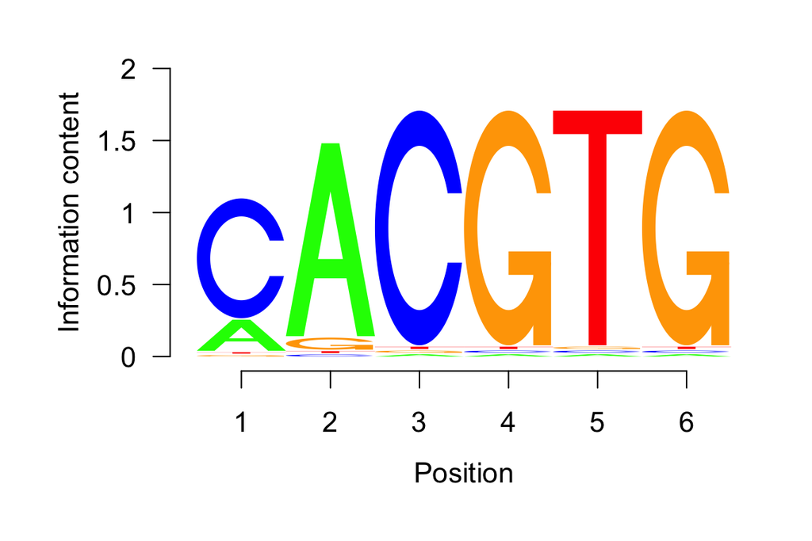

```r
seqLogo(icm)
```

## 4.3 Align PFM to a custom matrix or IUPAC string

In some cases, it is beneficial to assess similarity of existing profile matrices, such as JASPAR, to a newly discovered matrix (as with using BLAST for sequence data comparison when using Genbank).

*TFBSTools* provides tools for comparing pairs of PFMs, or a PFM with IUPAC string, using a modified Needleman-Wunsch algorithm (Sandelin et al. 2003).

```r
## one to one comparison
data(MA0003.2)
data(MA0004.1)
pfmSubject <- MA0003.2
pfmQuery <-  MA0004.1
PFMSimilarity(pfmSubject, pfmQuery)
```

```
#>     score  relScore
#>  7.294736 60.789466
```

```r
## one to several comparsion
PFMSimilarity(pfmList, pfmQuery)
```

```
#> $pfm1
#>    score relScore
#>       12      100
#>
#> $pfm2
#>    score relScore
#>       12      100
```

```r
## align IUPAC string
IUPACString <- "ACGTMRWSYKVHDBN"
PFMSimilarity(pfmList, IUPACString)
```

```
#> $pfm1
#>    score relScore
#>  8.81500 73.45833
#>
#> $pfm2
#>    score relScore
#>  8.81500 73.45833
```

## 4.4 PWM similarity

To measure the similarity of two PWM matrix in three measurements: *normalised Euclidean distance*, *Pearson correlation* and *Kullback Leibler divergence* (Linhart, Halperin, and Shamir 2008). Given two PWMs in probability type, $P^1$ and $P^2$, where $l$ is the length. $P^j_{i,b}$ is the values in column $i$ with base $b$ in PWM $j$. The normalised Euclidean distance is computed in

$$D(P^1, P^2) = {1 \over {\sqrt{2}l}} \cdot \sum_{i=1}^{l} \sqrt{\sum_{b \in {\{A,C,G,T\}}} (P_{i,b}^1-P_{i,b}^2)^2}$$

This distance is between 0 (perfect identity) and 1 (complete dis-similarity).

The pearson correlation coefficient is computed in

$$r(P^1, P^2) = {1 \over l} \cdot \sum_{i=1}^l {\sum_{b \in \{A,C,G,T\}} (P_{i,b}^1 - 0.25)(P_{i,b}^2-0.25) \over \sqrt{\sum_{b \in \{A,C,G,T\}} (P_{i,b}^1 - 0.25)^2 \cdot \sum_{b \in \{A,C,G,T\}} (P_{i,b}^2 - 0.25)^2}}$$

The Kullback-Leibler divergence is computed in

$$KL(P^1, P^2) = {1 \over {2l}} \cdot \sum_{i=1}^l \sum_{b \in \{A,C,G,T\}} (P_{i,b}^1\log{ P_{i,b}^1 \over P_{i,b}^2}+ P_{i,b}^2\log{P_{i,b}^2 \over {P_{i,b}^1}})$$

```r
data(MA0003.2)
data(MA0004.1)
pwm1 <- toPWM(MA0003.2, type="prob")
pwm2 <- toPWM(MA0004.1, type="prob")
PWMSimilarity(pwm1, pwm2, method="Euclidean")
```

```
#> [1] 0.5134956
```

```r
PWMSimilarity(pwm1, pwm2, method="Pearson")
```

```
#> [1] 0.2828507
```

```r
PWMSimilarity(pwm1, pwm2, method="KL")
```

```
#> [1] 2.385866
```

## 4.5 Dynamic random profile generation

In this section, we will demonstrate the capability of random profile matrices generation with matrix permutation and probabilitis sampling. In many computational/simulation studies, it is particularly desired to have a set of random matrices. Some cases includes the estimation of distance between putative TFBS and transcription start site, the evaluation of comparison between matrices (Bryne et al. 2008). These random matrices are expected to have same statistical properties with the selcted profiles, such as nucleotide content or information content.

The permutation method is relatively easy. It simply shuffles the columns either constrainted in each matrix, or columns almong all selected matrices. The probabilistic sampling is more complicated and can be done in two steps:

1. A Dirichlet multinomial mixture model is trained on all available matrices in JASPAR.
2. Random columns are sampled from the posterior distribution of the trained Dirichlet model based on selected profiles.

```r
## Matrice permutation
permuteMatrix(pfmQuery)
```

```
#> An object of class PFMatrix
#> ID: MA0004.1
#> Name: Arnt
#> Matrix Class: Zipper-Type
#> strand: +
#> Tags:
#> $comment
#> [1] "-"
#>
#> $family
#> [1] "Helix-Loop-Helix"
#>
#> $medline
#> [1] "7592839"
#>
#> $pazar_tf_id
#> [1] "TF0000003"
#>
#> $tax_group
#> [1] "vertebrates"
#>
#> $tfbs_shape_id
#> [1] "11"
#>
#> $tfe_id
#> [1] "580"
#>
#> $type
#> [1] "SELEX"
#>
#> $collection
#> [1] "CORE"
#>
#> $species
#> [1] "10090"
#>
#> $acc
#> [1] "P53762"
#>
#> Background:
#>    A    C    G    T
#> 0.25 0.25 0.25 0.25
#> Matrix:
#>   [,1] [,2] [,3] [,4] [,5] [,6]
#> A    0    0    0    0    4   19
#> C    0    0    0   20   16    0
#> G   20    0   20    0    0    1
#> T    0   20    0    0    0    0
```

```r
permuteMatrix(pfmList, type="intra")
```

```
#> PFMatrixList of length 2
#> names(2): pfm1 pfm2
```

```r
permuteMatrix(pfmList, type="inter")
```

```
#> PFMatrixList of length 2
#> names(2): pfm1 pfm2
```

```r
## Dirichlet model training
data(MA0003.2)
data(MA0004.1)
pfmList <- PFMatrixList(pfm1=MA0003.2, pfm2=MA0004.1, use.names=TRUE)
dmmParameters <- dmmEM(pfmList, K=6, alg="C")
## Matrice sampling from trained Dirichlet model
pwmSampled <- rPWMDmm(MA0003.2, dmmParameters$alpha0, dmmParameters$pmix,
                      N=1, W=6)
```

# 5 TFFM methods

## 5.1 The graphical representation of TFFM

Basic PWMs can be graphically represented by the sequence logos shown above. A novel graphical representation of TFFM is requied for taking the dinucleotide dependence into account.

For the upper part of the sequence logo, we represent the nucleotide probabilities at position $p$ for each possible nucleotide at position $p-1$. Hence, each column represents a position within a TFBS and each row the nucleotide probabilities found at that position. Each row assumes a specific nucleotide has been emitted by the previous hidden state. The intersection between a column corresponding to position $p$ and row corresponding to nucleotide $n$ gives the probabilities of getting each nucleotide at position $p$ if $n$ has been seen at position $p-1$. The opacity to represent the sequence logo is proportional to the probablity of possible row to be used by the TFFM.

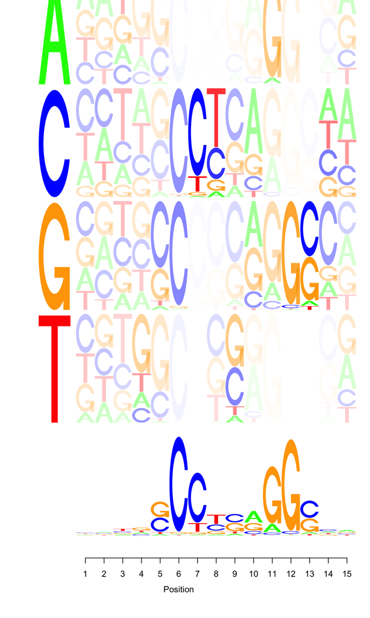

```r
  ## sequence logo for First-order TFFM
  seqLogo(tffmFirst)
```

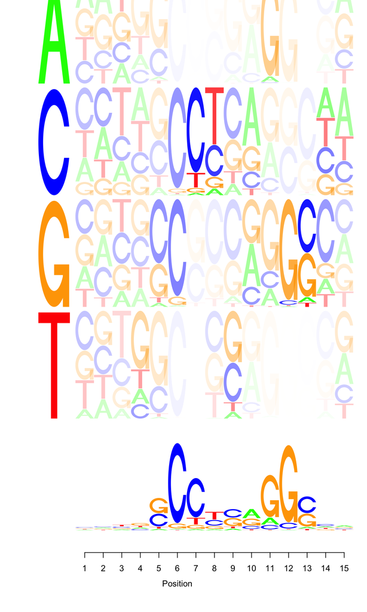

```r
  ## sequence logo for detailed TFFM
  seqLogo(tffmDetail)
```

# 6 Scan sequence and alignments with PWM pattern

## 6.1 searchSeq

`searchSeq` scans a nucleotide sequence with the pattern represented in the PWM. The strand argument controls which strand of the sequence will be searched. When it is _*_, both strands will be scanned.

A `SiteSet` object will be returned which can be exported into GFF3 or GFF2 format. Empirical p-values for the match scores can be calculated by an exact method from *TFMPvalue* or the distribution of sampled scores.

```r
library(Biostrings)
data(MA0003.2)
data(MA0004.1)
pwmList <- PWMatrixList(MA0003.2=toPWM(MA0003.2), MA0004.1=toPWM(MA0004.1),
                        use.names=TRUE)
subject <- DNAString("GAATTCTCTCTTGTTGTAGTCTCTTGACAAAATG")
siteset <- searchSeq(pwm, subject, seqname="seq1", min.score="60%", strand="*")

sitesetList <- searchSeq(pwmList, subject, seqname="seq1",
                         min.score="60%", strand="*")


## generate gff2 or gff3 style output
head(writeGFF3(siteset))
```

```
#>   seqname source feature start end     score strand frame
#> 1    seq1   TFBS    TFBS     8  13 -1.888154      +     .
#> 2    seq1   TFBS    TFBS    21  26 -1.888154      +     .
#> 3    seq1   TFBS    TFBS    29  34 -3.908935      +     .
#> 4    seq1   TFBS    TFBS     8  13 -1.961403      -     .
#> 5    seq1   TFBS    TFBS    10  15 -3.908935      -     .
#> 6    seq1   TFBS    TFBS    21  26 -1.961403      -     .
#>                                  attributes
#> 1 TF=Arnt;class=Zipper-Type;sequence=CTCTTG
#> 2 TF=Arnt;class=Zipper-Type;sequence=CTCTTG
#> 3 TF=Arnt;class=Zipper-Type;sequence=AAAATG
#> 4 TF=Arnt;class=Zipper-Type;sequence=CAAGAG
#> 5 TF=Arnt;class=Zipper-Type;sequence=AACAAG
#> 6 TF=Arnt;class=Zipper-Type;sequence=CAAGAG
```

```r
head(writeGFF3(sitesetList))
```

```
#>            seqname source feature start end      score strand frame
#> MA0003.2      seq1   TFBS    TFBS    18  32 -16.437682      -     .
#> MA0004.1.1    seq1   TFBS    TFBS     8  13  -1.888154      +     .
#> MA0004.1.2    seq1   TFBS    TFBS    21  26  -1.888154      +     .
#> MA0004.1.3    seq1   TFBS    TFBS    29  34  -3.908935      +     .
#> MA0004.1.4    seq1   TFBS    TFBS     8  13  -1.961403      -     .
#> MA0004.1.5    seq1   TFBS    TFBS    10  15  -3.908935      -     .
#>                                                      attributes
#> MA0003.2   TF=TFAP2A;class=Zipper-Type;sequence=TTTTGTCAAGAGACT
#> MA0004.1.1            TF=Arnt;class=Zipper-Type;sequence=CTCTTG
#> MA0004.1.2            TF=Arnt;class=Zipper-Type;sequence=CTCTTG
#> MA0004.1.3            TF=Arnt;class=Zipper-Type;sequence=AAAATG
#> MA0004.1.4            TF=Arnt;class=Zipper-Type;sequence=CAAGAG
#> MA0004.1.5            TF=Arnt;class=Zipper-Type;sequence=AACAAG
```

```r
head(writeGFF2(siteset))
```

```
#>   seqname source feature start end     score strand frame
#> 1    seq1   TFBS    TFBS     8  13 -1.888154      +     .
#> 2    seq1   TFBS    TFBS    21  26 -1.888154      +     .
#> 3    seq1   TFBS    TFBS    29  34 -3.908935      +     .
#> 4    seq1   TFBS    TFBS     8  13 -1.961403      -     .
#> 5    seq1   TFBS    TFBS    10  15 -3.908935      -     .
#> 6    seq1   TFBS    TFBS    21  26 -1.961403      -     .
#>                                          attributes
#> 1 TF "Arnt"; class "Zipper-Type"; sequence "CTCTTG"
#> 2 TF "Arnt"; class "Zipper-Type"; sequence "CTCTTG"
#> 3 TF "Arnt"; class "Zipper-Type"; sequence "AAAATG"
#> 4 TF "Arnt"; class "Zipper-Type"; sequence "CAAGAG"
#> 5 TF "Arnt"; class "Zipper-Type"; sequence "AACAAG"
#> 6 TF "Arnt"; class "Zipper-Type"; sequence "CAAGAG"
```

```r
## get the relative scores
relScore(siteset)
```

```
#> [1] 0.6652185 0.6652185 0.6141340 0.6633668 0.6141340 0.6633668
```

```r
relScore(sitesetList)
```

```
#> $MA0003.2
#> [1] 0.6196884
#>
#> $MA0004.1
#> [1] 0.6652185 0.6652185 0.6141340 0.6633668 0.6141340 0.6633668
```

```r
## calculate the empirical p-values of the scores
pvalues(siteset, type="TFMPvalue")
```

```
#> [1] 0.02734375 0.02734375 0.04638672 0.04052734 0.04638672 0.04052734
```

```r
pvalues(siteset, type="sampling")
```

```
#> [1] 0.0248 0.0248 0.0589 0.0383 0.0589 0.0383
```

## 6.2 searchAln

```r
library(Biostrings)
data(MA0003.2)
pwm <- toPWM(MA0003.2)
aln1 <- DNAString("ACTTCACCAGCTCCCTGGCGGTAAGTTGATC---AAAGG---AAACGCAAAGTTTTCAAG")
aln2 <- DNAString("GTTTCACTACTTCCTTTCGGGTAAGTAAATATATAAATATATAAAAATATAATTTTCATC")
sitePairSet <- searchAln(pwm, aln1, aln2, seqname1="seq1", seqname2="seq2",
                         min.score="50%", cutoff=0.5,
                         strand="*", type="any")
## generate gff style output
head(writeGFF3(sitePairSet))
```

```
#>   seqname source feature start end      score strand frame
#> 1    seq1   TFBS    TFBS     6  20  -9.515444      +     .
#> 2    seq1   TFBS    TFBS     7  21 -13.348617      +     .
#> 3    seq1   TFBS    TFBS     8  22 -13.182322      +     .
#> 4    seq1   TFBS    TFBS     9  23  -3.729917      +     .
#> 5    seq1   TFBS    TFBS    10  24  -7.677850      +     .
#> 6    seq1   TFBS    TFBS    14  28 -20.774619      +     .
#>                                             attributes
#> 1 TF=TFAP2A;class=Zipper-Type;sequence=ACCAGCTCCCTGGCG
#> 2 TF=TFAP2A;class=Zipper-Type;sequence=CCAGCTCCCTGGCGG
#> 3 TF=TFAP2A;class=Zipper-Type;sequence=CAGCTCCCTGGCGGT
#> 4 TF=TFAP2A;class=Zipper-Type;sequence=AGCTCCCTGGCGGTA
#> 5 TF=TFAP2A;class=Zipper-Type;sequence=GCTCCCTGGCGGTAA
#> 6 TF=TFAP2A;class=Zipper-Type;sequence=CCTGGCGGTAAGTTG
```

```r
head(writeGFF2(sitePairSet))
```

```
#>   seqname source feature start end      score strand frame
#> 1    seq1   TFBS    TFBS     6  20  -9.515444      +     .
#> 2    seq1   TFBS    TFBS     7  21 -13.348617      +     .
#> 3    seq1   TFBS    TFBS     8  22 -13.182322      +     .
#> 4    seq1   TFBS    TFBS     9  23  -3.729917      +     .
#> 5    seq1   TFBS    TFBS    10  24  -7.677850      +     .
#> 6    seq1   TFBS    TFBS    14  28 -20.774619      +     .
#>                                                     attributes
#> 1 TF "TFAP2A"; class "Zipper-Type"; sequence "ACCAGCTCCCTGGCG"
#> 2 TF "TFAP2A"; class "Zipper-Type"; sequence "CCAGCTCCCTGGCGG"
#> 3 TF "TFAP2A"; class "Zipper-Type"; sequence "CAGCTCCCTGGCGGT"
#> 4 TF "TFAP2A"; class "Zipper-Type"; sequence "AGCTCCCTGGCGGTA"
#> 5 TF "TFAP2A"; class "Zipper-Type"; sequence "GCTCCCTGGCGGTAA"
#> 6 TF "TFAP2A"; class "Zipper-Type"; sequence "CCTGGCGGTAAGTTG"
```

```r
## search the Axt alignment
library(CNEr)
axtFilesHg19DanRer7 <- file.path(system.file("extdata", package="TFBSTools"),
                                 "hg19.danRer7.net.axt")
axtHg19DanRer7 <- readAxt(axtFilesHg19DanRer7)
```

```
#> The number of axt files 1
#> The number of axt alignments is 133
```

```r
sitePairSet <-  searchAln(pwm, axtHg19DanRer7, min.score="80%",
                          windowSize=51L, cutoff=0.7, strand="*",
                          type="any", conservation=NULL, mc.cores=1)
GRangesTFBS <- toGRangesList(sitePairSet, axtHg19DanRer7)
GRangesTFBS$targetTFBS
```

```
#> GRanges object with 33 ranges and 5 metadata columns:
#>        seqnames            ranges strand |   matrix.ID matrix.strand
#>           <Rle>         <IRanges>  <Rle> | <character>   <character>
#>    [1]    chr11 31128026-31128040      + |    MA0003.2             +
#>    [2]    chr11 31128028-31128042      + |    MA0003.2             -
#>    [3]    chr11 31437161-31437175      + |    MA0003.2             +
#>    [4]    chr11 31437163-31437177      + |    MA0003.2             -
#>    [5]    chr11 31499628-31499642      + |    MA0003.2             +
#>    ...      ...               ...    ... .         ...           ...
#>   [29]    chr11 32198154-32198168      + |    MA0003.2             +
#>   [30]    chr11 32221916-32221930      + |    MA0003.2             +
#>   [31]    chr11 32221918-32221932      + |    MA0003.2             -
#>   [32]    chr11 32456353-32456367      + |    MA0003.2             +
#>   [33]    chr11 32456355-32456369      + |    MA0003.2             -
#>               abs.score         rel.score        sitesSeq
#>               <numeric>         <numeric>  <DNAStringSet>
#>    [1] 2.08909296649847 0.813035307568094 GGCCCCCCGTGGCGT
#>    [2] 1.40495684322417 0.805895608242819 CCCCCCGTGGCGTTT
#>    [3]  7.7859951557856  0.87248863466672 ACTGGCCTAGGGACA
#>    [4] 7.79663297680509  0.87259965181809 TGGCCTAGGGACAGG
#>    [5] 2.23903150474715 0.814600078150947 TCTGACCCAGAGGCA
#>    ...              ...               ...             ...
#>   [29] 2.51181373192229 0.817446855301068 ACCGTCTTTAGGGGA
#>   [30] 4.67226077808012 0.839993453548098 TCTACCCTCGAGCAC
#>   [31]  10.609562224018 0.901955606525251 TACCCTCGAGCACTG
#>   [32] 4.20454313190578 0.835112314767079 AAGGGCCCGTAGCGA
#>   [33] 1.17696523208494 0.803516269545677 GGGCCCGTAGCGACA
#>   -------
#>   seqinfo: 3 sequences from an unspecified genome; no seqlengths
```

```r
GRangesTFBS$queryTFBS
```

```
#> GRanges object with 33 ranges and 5 metadata columns:
#>        seqnames            ranges strand |   matrix.ID matrix.strand
#>           <Rle>         <IRanges>  <Rle> | <character>   <character>
#>    [1]    chr25 15057430-15057444      + |    MA0003.2             +
#>    [2]    chr25 15057432-15057446      + |    MA0003.2             -
#>    [3]    chr25 15149515-15149529      + |    MA0003.2             +
#>    [4]    chr25 15149517-15149531      + |    MA0003.2             -
#>    [5]    chr25 15163682-15163696      + |    MA0003.2             +
#>    ...      ...               ...    ... .         ...           ...
#>   [29]    chr25 15359169-15359183      + |    MA0003.2             +
#>   [30]    chr25 15472022-15472036      + |    MA0003.2             +
#>   [31]    chr25 15472024-15472038      + |    MA0003.2             -
#>   [32]    chr25 15570786-15570800      + |    MA0003.2             +
#>   [33]    chr25 15570789-15570803      + |    MA0003.2             -
#>               abs.score         rel.score        sitesSeq
#>               <numeric>         <numeric>  <DNAStringSet>
#>    [1] 2.65651612039436  0.81895698100587 GGCCCCCTGCGGCTC
#>    [2] 5.00568386486403 0.843473083561419 CCCCCTGCGGCTCTC
#>    [3] 5.68610472295397 0.850574010081944 TCTCGCCTAAGGAAA
#>    [4] 6.43485320793907 0.858388009184146 TCGCCTAAGGAAAAA
#>    [5] 1.49257293388735 0.806809976775791 TGCCACCCTTGGGCA
#>    ...              ...               ...             ...
#>   [29] 3.13473647571757 0.823947726899966 ACCATCTTTAGGGGA
#>   [30]  1.3405691292826 0.805223652907988 TCTCCCCTCCAGCTC
#>   [31] 5.67418566145658 0.850449621802425 TCCCCTCCAGCTCTG
#>   [32] 1.60462132547211 0.807979322756189 CCGTACCTGCAGGCC
#>   [33] 5.26177139428999 0.846145633509963 TACCTGCAGGCCCCT
#>   -------
#>   seqinfo: 3 sequences from an unspecified genome; no seqlengths
```